[figure not shown]

ANÁLISIS DE SENDEROS (III)Gabriel Sotomayor

Junio 2023

CONTENIDOS

Efectos indirectos (medicación) en sociología.

Construcción de diagramas de senderos en lavaan

Interpretación de coeficientes.

Estadísticos de ajustes.

Significación estadística en regresiones y análisis de senderos.

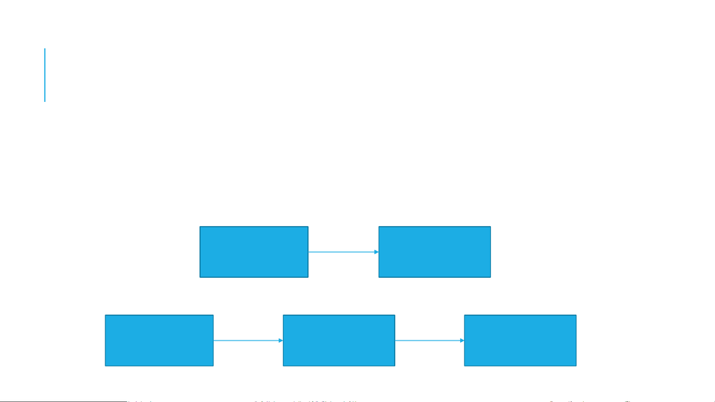

EFECTOS INDIRECTOS

El análisis de senderos es útil para la investigación sociológica porque nos permite

analizar relaciones más complejas entre variables que las que permite una regresión

lineal múltiple.

•Efectos directos: influencia inmediata de una variable sobre otra.

•Efectos indirectos: influencia mediada por una o más variables intermedias.

Ingresos

Horas dedicadas

al trabajo

doméstico

Ingresos

Contratación de

trabajo doméstico

remunerado

Horas dedicadas

al trabajo

doméstico

ACTIVIDAD 1: TRANSFORMEN LOS SIGUIENTES

PLANTEAMIENTOS EN DIAGRAMAS

1. La esperanza de vida es afectada por el consumo de drogas. La posibilidad de consumir

drogas también está influenciada por el ingreso, el cual a su vez también afecta la

esperanza de vida.

2. La calidad del ambiente en el hogar afecta el desarrollo cognitivo infantil, el cual a su vez

afecta el rendimiento escolar. La calidad del ambiente del hogar también afecta el

desarrollo emocional infantil, el cual a su vez afecta la autoeficacia, lo cual afecta a su

vez del rendimiento escolar. El ingreso afecta el rendimiento escolar, así como también la

calidad del ambiente en el hogar.

3. La clase social afecta la participación en protestas de manera indirecta a partir de 3 vías.

Por un lado, afecta la “Percepción identidad agraviada”, que a su vez afecta la

“Justificación exogrupal del agravio” (que este es causado por otro grupo externo), que a

su vez afecta la participación en protestas. Por otro lado la posición de clase afecta la

percepción de eficacia de las protestas que afecta la participación en estas. Por último la

posición de clase afecta la legitimidad atribuida a las protestas, que a su vez afecta la

participación en protestas.

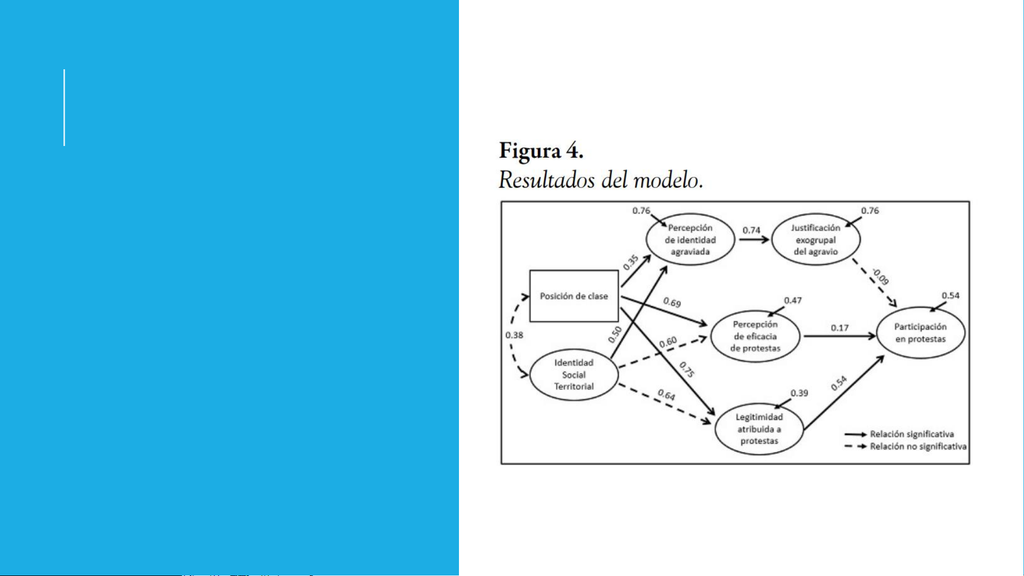

RECUPERANDO LA CLASE SOCIAL EN EL

ESTUDIO DE LA ACCIÓN COLECTIVA. EL

CASO DE UN MOVIMIENTO

SOCIOAMBIENTAL CHILENO

Respecto a la posición de clase,

esta sí tiene un efecto indirecto

total significativo (p < 0.001) y

fuerte (r 2 = 0.29) sobre la

participación en protestas

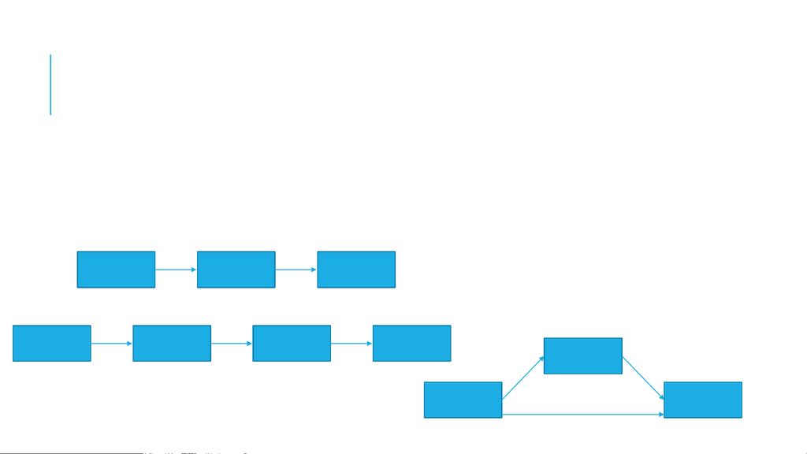

ACTIVIDAD 2:EFECTOS INDIRECTOS

En grupo de 2 o 3 personas, piensen en al menos 3 efectos indirectos que podríamos

medir en sociología. Redacten las hipótesis propuestas (una por relación).

Para esto deben al menos contar con una variable independiente, una interviniente y

una dependiente.

También puede haber otras formas:

[figure not shown]

CONSTRUCCIÓN DE

DIAGRAMAS DE

SENDEROS EN LAVAAN

Para evaluar los modelos de

análisis factorial confirmatorio y

de senderos (y ecuaciones

estructurales) en R, necesitamos

expresarlos mediante el

lenguaje de fórmulas del

paquete lavaan.

Sintaxis

Comando

Ejemplo

~

Regresar en

Regresar

B sobre A:

B ~ A

~~

(Co)varianza

Varianza de A:

A ~~ A

=~

Definir variable

latente

Definir Factor 1 por

A

-D: F1 =~ A + B + C

+ D

:=

Definir parámetro

fuera del modelo

Definir parámetro u2

como doble del

cuadrado de u: u2 :=

2*(u^2)

Etiquetar

parámetros

(etiqueta antes de

símbolo)

Etiquetar la regresión

de Z sobre X como b: Z

~ b*X

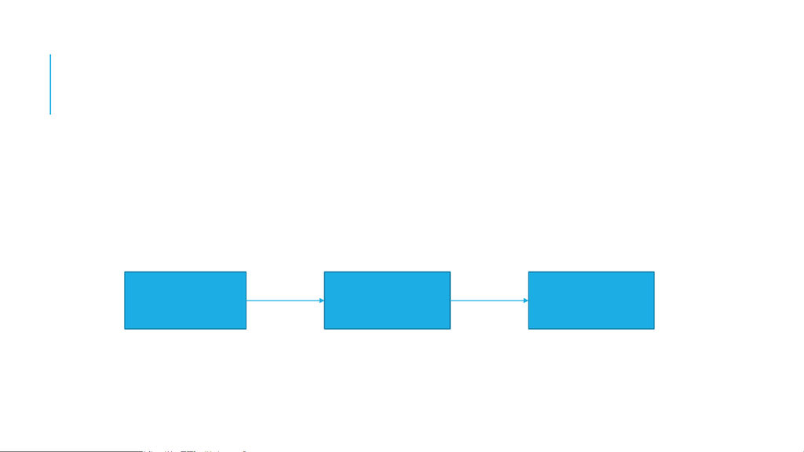

EJEMPLO

En este caso, siendo ingresos “ing”, contratación de trabajo doméstico “ctd” y horas

dedicadas al trabajo domestico “htd”, la formula quedaría definida de la siguiente

manera:

mod_sendero <- ‘ctd ~ ing

htd~ ctd’

Ahora practiquemos con algunos ejemplos.

Como criterio general, cada variable endógena (con flechas apuntándole), será una

línea de la especificación del modelo.

Ingresos

Contratación de

trabajo doméstico

remunerado

Horas dedicadas

al trabajo

doméstico

[figure not shown]

EJERCICIO 3

Escribamos los diagramas

confeccionados en el ejercicio

1 y ejercicio 2 a partir de la

sintaxis de formulas de

lavaan.

Sintaxis

Comando

Ejemplo

~

Regresar en

Regresar

B sobre A:

B ~ A

~~

(Co)varianza

Varianza de A:

A ~~ A

=~

Definir variable

latente

Definir Factor 1 por

A

-D: F1 =~ A + B + C

+ D

:=

Definir parámetro

fuera del modelo

Definir parámetro u2

como doble del

cuadrado de u: u2 :=

2*(u^2)

Etiquetar

parámetros

(etiqueta antes de

símbolo)

Etiquetar la regresión

de Z sobre X como b: Z

~ b*X

INTERPRETACIÓN DE COEFICIENTES PATH

Coeficientes path: indican la magnitud y el signo del efecto de una variable sobre otra

variable endógena, representan el efecto de una variable sobre otra, controlando el resto de

las variables. Corresponden a coeficientes estandarizados.

castigo_media ~ rwa_media (0.284, p < 0.001):

Interpretación para una variable intervalar: por cada desviación estándar que aumenta en

el "autoritarismo de derechas" (rwa_media), se espera que el "castigo severo"

(castigo_media) aumente en promedio en 0.284 desviaciones estándar, controlando por las

demás variables del modelo.

Interpretación para una variable nominal: En promedio, ser de izquierdas está asociado con

modelo.

INTERPRETACIÓN DE COEFICIENTES PATH

Componentes de la interpretación:

•Tamaño.

•Dirección.

•Control estadístico.

•Efecto promedio (o predicho por el modelo).

•Significación estadística.

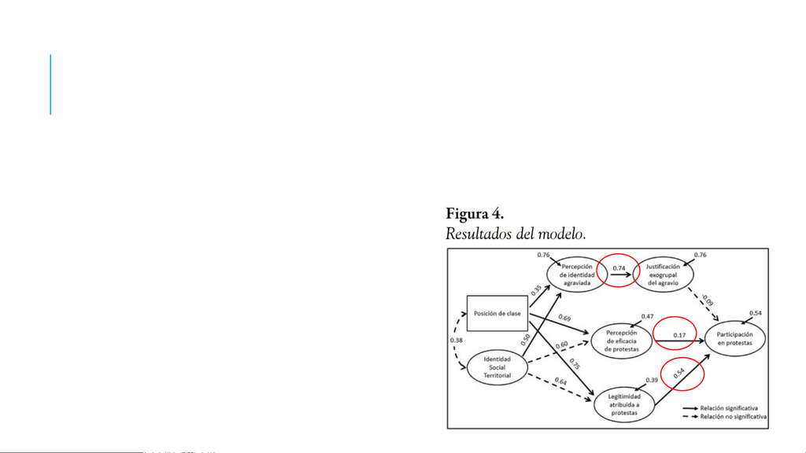

EJERCICIO 4

Escriban (escriban!!) la interpretación de los siguientes coeficientes path,

considerando todos los elementos señalados.

•Tamaño.

•Dirección.

•Control estadístico.

•Efecto promedio (o predicho por el modelo).

Interpretación para una variable intervalar: por cada

desviación estándar que aumenta en el "autoritarismo de

derechas" (rwa_media), se espera que el "castigo

severo" (castigo_media) aumente en promedio en 0.284

desviaciones estándar, controlando por las demás variables

del modelo.

[figure not shown]

¿POR QUÉ USAMOS MUESTRAS?

Usamos muestras porque nos permiten obtener datos representativos de una población a partir de una

selección aleatoria de casos, una muestra. Este proceso se llama estimación: la estimación de un

parámetro poblacional a partir de un estadístico muestral.

¿Porqué es esto posible?

Sabemos que la representatividad es posible, gracias a dos leyes estadísticas esenciales:

•El teorema del límite central -> La distribución de medias muestrales extraídas de forma aleatoria de

una población, se aproxima a la distribución normal a medida que aumenta el tamaño de la muestra.

•La ley de los grandes números -> la diferencia entre el estadístico muestral y el parámetro

poblacional tiende a 0 cuando el tamaño de la muestra tiende al infinito.

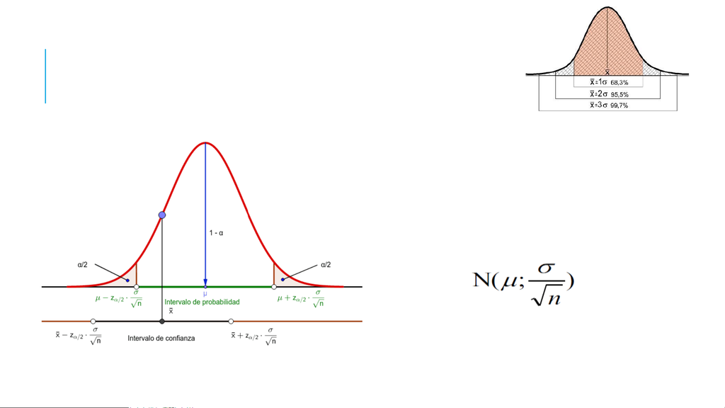

DISTRIBUCIONES MUESTRALES

A partir del Teorema del Límite central,

vimos que la media de las distintas

muestras que podemos extraer de una

población se distribuye de forma

normal, con muestras suficientemente

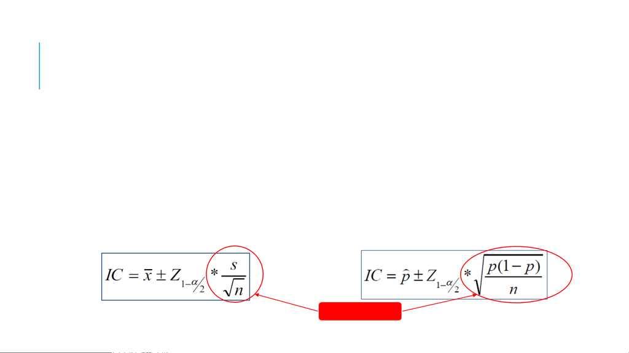

INTERVALOS DE CONFIANZA

Medias Proporciones

Estimación de punto: Puede ser útil cuando solo tenemos la media (o proporción) muestral y no contamos

con más información, sin embargo no sabemos la precisión (el error) de nuestra medición.

Estimación de Intervalo: Podemos calcularlo a partir de las propiedades de la distribución muestral de las

medias, usando los estadísticos muestrales como estimadores de los parámetros poblacionales para calcular

el error estándar.

Error estándar

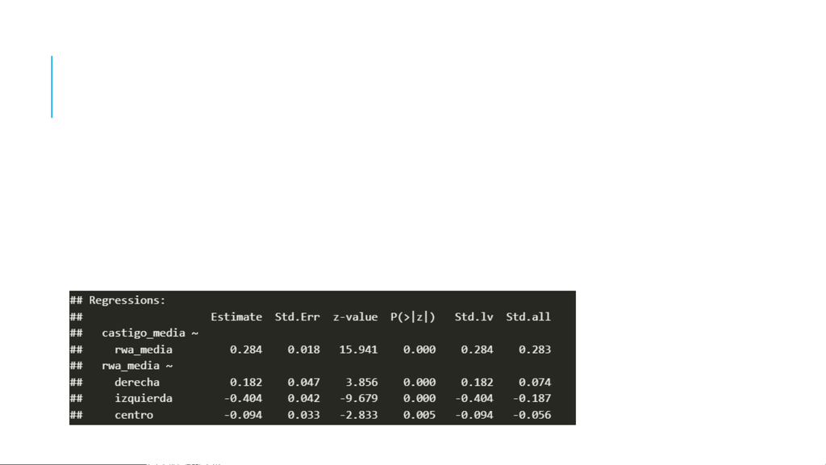

INFERENCIA EN ANÁLISIS DE SENDEROS

Al interpretar nuestros resultados queremos saber si contamos con evidencia

suficiente para señalar las relaciones que observamos en nuestra muestra son

estadísticamente significativas, es decir, si es probable que estas existan en la

población.

Para esto debemos comparar el coeficiente path con su error estándar.

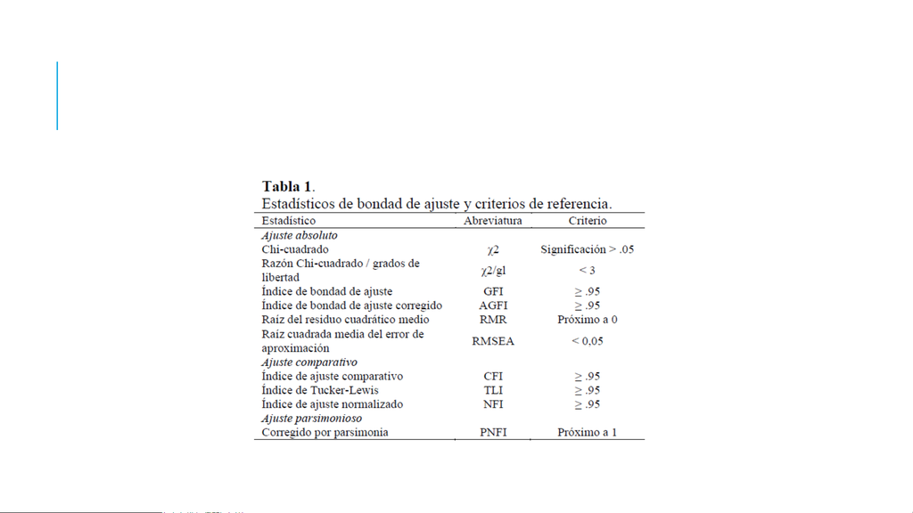

EVALUACIÓN DE AJUSTE